# Unit 3 Project

## Question 3

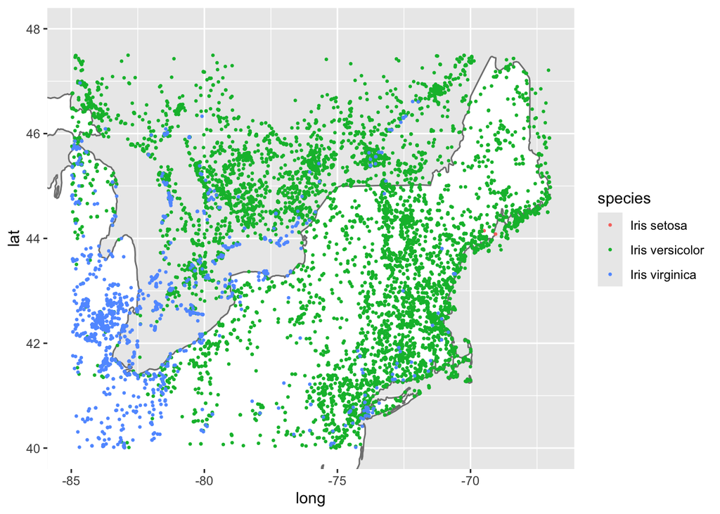

```r
us_north_east_iris_gps <- us_iris_gps %>% filter(lat > 40, lat <= 47.5, lon > -85, lon <= -67)

ggplot(us.map, aes(long, lat, group = group)) + geom_polygon(fill = "white", colour = "grey50") + coord_quickmap() + geom_point(data = us_north_east_iris_gps, mapping = aes(x = lon, y = lat, group = species, color = species), size = 0.5) + coord_cartesian(xlim = c(-85,-67), ylim = c(40,48))
```

## Question 4

Iris setosa is the least distributed in the Northeast region of the U.S, iris versicolor covers mostly the eastern side of the Northeast region while Iris virginica covers mostly the western side. Both iris veriscolor and iris virginica overlap within the middle region of the Northeast, and iris setosa overlaps a small area in the east-most side with iris versicolor. This tells us that iris setosa lives separately from the other two species, and iris versicolor and iris virginica have overlapping areas, but have certain zones that they live in. If the three species share similar distribution in the Northeast region of the U.S, the species delineation may be based off genetic differences and/or temporal differences and possibly supports the prediction of iris versicolor being a hybrid.

## Question 5

Using only geographical and temporal data to evaluate reproductive isolation is problematic because it does not account for all other possible barriers if the data were to overlap. For example, iris versicolor and iris virginica overlap in both geographical distribution and times of flowering, which does not distinguish them from each other as species. Other factors such as behavior, mechanical parts of the flowers, and gametic compatibility are not accounted for when evaluating reproductive isolation based solely off geographical and temporal data.

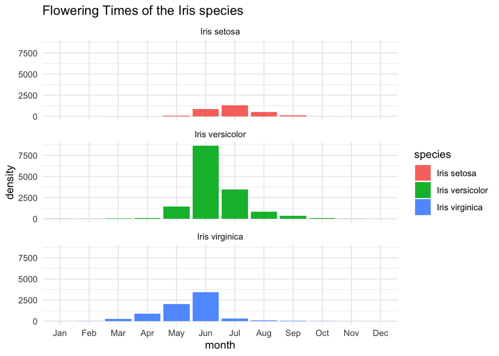

```r
temporal_iris_gps <- iris_gps %>% dplyr::select(species,month) %>% mutate(month_name = factor(month, levels = 1:12, labels = c("Jan", "Feb", "Mar", "Apr", "May", "Jun", "Jul", "Aug", "Sep", "Oct", "Nov", "Dec"))) %>% drop_na(month)


ggplot(data = temporal_iris_gps, aes(x = month_name, group = species, fill = species)) + geom_bar(position = "dodge", binwidth = 1) + facet_wrap(~species, nrow = 3) + labs(x = "month", y = "density", title = "Flowering Times of the Iris species") +theme_minimal()
```